# Elecciones Regionales y Municipales (ERM) 2018 - Análisis de resultados

Curso: POL304 - Estadística para el análisis político 2

Alexander Benites

Octubre, 2022

El objetivo de este breve reporte es analizar los resultados de las Elecciones Regionales y Municipales (ERM) del año 2018, todo ello con el objetivo de entender en mayor profundidad las dinámicas del comportamiento político-electoral a nivel subnacional, específicamente en la provincia de Lima. Para ello, se llevarán a cabo los siguientes análisis:

- Realizar un análisis descriptivo y georreferenciado de los resultados a nivel distrital
- Aplicar técnicas de reducción de dimensiones para agrupar a los distritos en función a sus características sociodemográficas
- Implementar técnicas multivariadas para modelar el comportamiento del voto, particularmente de la organización ganadora

### 1. Análisis rápido de los resultados:

En promedio, los distritos de Lima presentaron un ausentismo del 18%. El porcentaje de ausentismo por distrito se puede observar en la tabla a continuación:

|  | DISTRITO | AUSENTISMO |
| --- | --- | --- |
| 1 | ANCON | 16.14 |
| 2 | ATE | 17.89 |
| 3 | BARRANCO | 19.3 |
| 4 | BREÑA | 17.79 |
| 5 | CARABAYLLO | 15.44 |
| 6 | CHACLACAYO | 18.22 |
| 7 | CHORRILLOS | 15.88 |
| 8 | CIENEGUILLA | 14.7 |
| 9 | COMAS | 15.89 |
| 10 | EL AGUSTINO | 15.5 |

[output cut: 33 more lines]

Contrario al escenario nacional, en el caso de la provincia de Lima, no son los distritos más pobres sino los de mayores recursos aquellos que presentan los porcentajes de ausentismo más elevados:

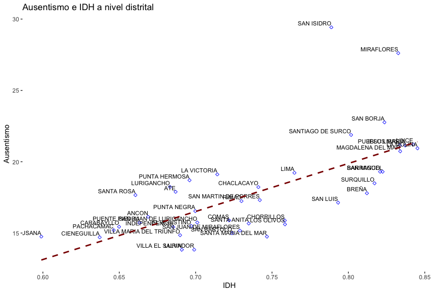

De los 43 distritos de la provincia de Lima, Acción Popular (AP), con la candidatura de Jorge Muñoz, ganó 40. Los tres distritos restantes tuvieron como organización ganadora a Podemos Perú, con la candidatura de Daniel Urresti. Territorialmente, los votos por AP se encuentran concentrados en los distritos del centro de la capital. Todo ello se puede observar en los mapas a continuación:

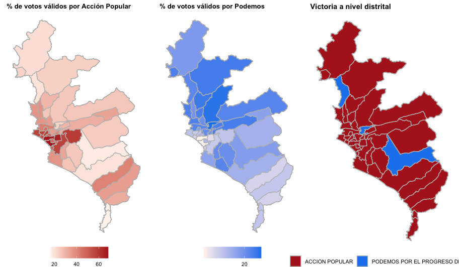

|  | ACCION POPULAR | PODEMOS POR EL PROGRESO DEL PERU |
| --- | --- | --- |
| Min. | 16.43000 | 7.99000 |
| 1st Qu. | 25.58500 | 13.12000 |
| Median | 34.55000 | 18.32000 |
| Mean | 37.29535 | 17.31791 |
| 3rd Qu. | 49.31000 | 21.55500 |
| Max. | 68.54000 | 24.90000 |

La distribución de votos de cada organización se puede osbervar en el gráfico a continuación:

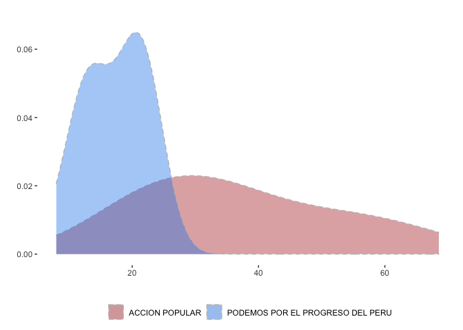

### 2. Técnicas de reducción de dimensiones

Vamos a agrupar a los distritos en función a sus características sociodemográficas, siguiendo técnicas de reducción de dimensiones. Tenemos tres estrategias: PAM, jerárquica y basada en densidad.

Hemos solicitado el número óptimo de clusters y son 3.

Nos quedamos con la estrategia de aglomeración jerarquica, bajo el algoritmo AGNES, que es el que ha demostrado mejor desempeño en el agrupamiento de casos.

```
##   cluster size ave.sil.width
## 1       1   14          0.46
## 2       2   14          0.61
## 3       3   15          0.35
```

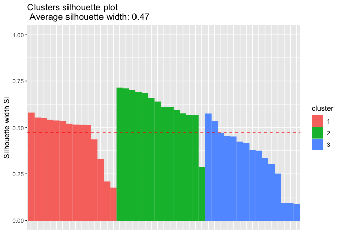

Características de cada conglomerado:

| clust | IDH | IVA | POBREZA | EXT_POBREZA | DISCAPACIDAD | MAS80 |
| --- | --- | --- | --- | --- | --- | --- |
| Vulnerabilidad alta | 0.6694212 | 0.2481595 | 19.425040 | 1.3062414 | 0.0068987 | 0.0101413 |
| Vulnerabilidad baja | 0.8217825 | 0.1021996 | 1.682594 | 0.0613696 | 0.0077140 | 0.0374251 |
| Vulnerabilidad media | 0.7297997 | 0.1695821 | 12.188866 | 0.4638205 | 0.0086664 | 0.0192914 |

Número de distritos por cada conglomerado:

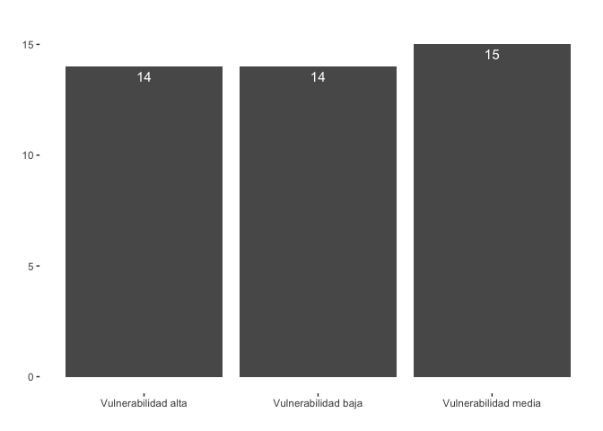

Análisis geoespacial de clusters:

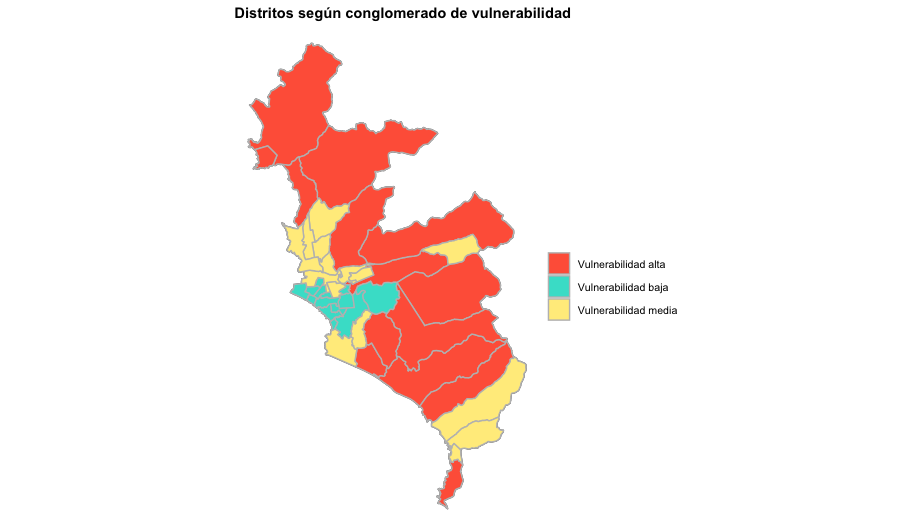

### 3. Modelando el voto

$$\operatorname{\widehat{AP}} = -50 + 118.33(\operatorname{IDH\_2019}) -
1182.23(\operatorname{tDISC}) + 471.77(\operatorname{tMAS80}) -
4.6(\operatorname{IVA}) - 0.07(\operatorname{POBREZA\_2019})$$

OLS

|  | Model 1 |
| --- | --- |
| (Intercept) | −49.998 |
|  | (42.045) |
| IDH_2019 | 118.333* |
|  | (50.451) |
| tDISC | −1182.233* |
|  | (545.186) |
| tMAS80 | 471.773** |
|  | (162.189) |
| IVA | −4.596 |
|  | (12.238) |
| POBREZA_2019 | −0.069 |
|  | (0.507) |
| Num.Obs. | 43 |
| R2 | 0.854 |
| R2 Adj. | 0.834 |
| AIC | 285.7 |
| BIC | 298.0 |
| Log.Lik. | −135.845 |
| F | 43.215 |
| RMSE | 5.70 |

+ p < 0.1, * p < 0.05, ** p < 0.01, *** p < 0.001